# TP 1

## Mise en situation

B.B.B. se prépare à développer leur premier jeu 3D avec Unity. Par contre, aucun prototype n’existe, à ce point. Ayant saisie les éléments essentiels du moteur Unity, votre équipe se proponse pour développer un prototype qui démontre les transformations 3D.

Vous avez la tâche de tester les fonctionnalités de transformation dans l’espace, afin de générer des animations et des effets. Vous devez créer trois composantes, chacune touchant une sorte de transformation (rotation, homothétie, translation) selon le FPS de la simulation. Une deuxième version de chaque composante devra aussi être conçue, mais ces versions devront transformer selon le temps réel.

## À propos des `Vector3`

Vous pouvez multiplier un `Vector3` par un scalaire à l’aide de l’opération `*`. Ceci retourne un **nouveau** vecteur. Vous pouvez aussi soustraire et additionner des `Vector3` ensemble avec les opérateur `-` et `+` respectivement. Ces opérations retourne également un nouveau vecteur.

## L’objet *GameManager*

Créez une objet de jeu dans la scène avec le nom *GameManager*. Cet objet possède la tâche de gérer le jeu dans son ensemble. Cette tâche inclut contrôller la valeur de FPS cible.

Attachez le script suivant à cet objet :

```
using UnityEngine;

//Avertissement : il est insensé d'avoir plus qu'un GO avec ce script
public class FrameRateControllerComponent : MonoBehaviour
{
    public int targetFrameRate = 60;

    void Awake()
    {
         QualitySettings.vSyncCount = 0;
         Application.targetFrameRate = targetFrameRate;
    }
}
```

Dans l’inspecteur, il est possible de changer la valeur de `targetFrameRate`. Par défaut, la valeur est de 60, ce qui implique une simulation qui cible rendre 60 FPS.

## `SpinComponent`

Cette composante doit faire tourner un *GameObject* sur lui-même en fonction du FPS.

### Attributs modifiables dans l’inspecteur

- `Vector3 rotationPerFrame` : vecteur qui représente la rotation à faire par frame. Chaque composante du vecteur exprime une rotation en degré sur son axe respectif;
- `Space space` : indique si la rotation doit se faire selon les axes de l’espace locale de l’objet ou selon les axes de l’espace du monde. La valeur peut être *Self* ou *World*.

### Comportements

En utilsant la composante `Transform` du *GameObject* possédant ce script, utilisez la méthode `Rotate(Vector3, Space)` accessible aux instances de `Transform` pour faire tourner le *GameObject*. Le *GameObject* doit tourner à chaque *frame* de la quantité donnée par `rotationPerFrame`.

### Tests

1. Fonctionalité
   - `targetFrameRate` : 60
   - `rotation` : $(0,0,0)$
   - `rotationPerFrame` : $(1,0,0)$
   - `space` : *Self*
2. Deux fois moins vite
   - `targetFrameRate` : 30
   - `rotation` : $(0,0,0)$
   - `rotationPerFrame` : $(1,0,0)$
   - `space` : *Self*
3. *World*
   - `targetFrameRate` : 60
   - `rotation` : $(0,0,90)$
   - `rotationPerFrame` : $(1,0,0)$
   - `space` : *World*
4. *Self*
   - `targetFrameRate` : 60
   - `rotation` : $(0,0,90)$
   - `rotationPerFrame` : $(1,0,0)$
   - `space` : *Self*

## `SpinComponentV2`

Cette composante doit faire tourner un *GameObject* sur lui-même en fonction du temps réel.

### Attributs à changer

- `Vector3 rotationPerFrame` → `Vector3 rotationPerSecond` : vecteur qui représente la rotation à faire par seconde. Chaque composante du vecteur exprime une rotation en degré sur son axe respectif;

### Tests

1. Fonctionalité
   - `targetFrameRate` : 60
   - `rotation` : $(0,0,0)$
   - `rotationPerSecond` : $(60,60,60)$
   - `space` : *Self*
2. Autant de rotation, mais deux fois moins de *frames*
   - `targetFrameRate` : 30
   - `rotation` : $(0,0,0)$
   - `rotationPerSecond` : $(60,60,60)$
   - `space` : *Self*

## `ScalePulsateComponent`

Cette composante doit faire varier l’échelle local du *GameObject* en fonction du FPS.

### Attributs modifiables dans l’inspecteur

- `float maxDeltaScale` : indique le delta maximum entre l’échelle originale et celui résultant des transformations. Par exemple, si le *GameObject* a un *scale* de $(2,2,2)$ et que `maxDeltaScale` est de 3, la composante doit faire varier le _scale entre $(2,2,2)$ et $(5,5,5)$;
- `float stepPerFrame` : indique la valeur à ajouter ou enlever à l’échelle du *GameObject* par frame.

### Comportements

Utilisez la propriété `localScale` accessible aux instances de `Transform` pour varier la taille du *GameObject*. Le *GameObject* doit agrandir ou rappetisser sur chaque axe à chaque *frame* de la quantité donnée par `stepPerFrame`. Une fois que la taille maximale est atteinte, le *GameObject* doit revenir à sa taille originale. Une fois rendu à ça taille originale, le *GameObject* doit recommencer à prendre de l’expansion. Par contre, il ne faut pas que la taille maximale soit dépassée, peu importe le `stepPerFrame` donné.

Par exemple, supossons que `maxDeltaScale` est de 2, que le *scale* original du *GameObject* est de $(1,1,1)$ et que *stepPerFrame* est de 1,5. Au premier `Update()`, l’échelle du `GameObject` augmente à $(2.5,2.5,2.5)$. Au prochain `Update()`, il ne faut pas que l’échelle deviennent $(4,4,4)$ mais plutôt $(3,3,3)$. L’échelle du *GameObject* ne doit pas baisser en dessous de sa valeur originale, semblablement. En autre mot, les valeurs d’échelle sont « serrées » (*clamped*).

Aussi, tenez pour acquis que l’utilisateur ne donne jamais une valeur négative pour `maxDeltaScale` et `stepPerFrame`.

### Tests

1. Fonctionalité simple
   - `targetFrameRate` : 1
   - `maxDeltaScale` : 2
   - `stepPerFrame` : 1
2. Fonctionalité « serrer »
   - `targetFrameRate` : 1
   - `maxDeltaScale` : 2
   - `stepPerFrame` : 1.5

### Nombre de lignes de code

La solution de l’enseignant a 9 lignes de code dans `Update` et aucun raccourci mystérieux hors de vos connaissances. Ce code contient qu’un seul `if`. Trouvez une solution et **ensuite** optimisez là pour viser qu’un seul `if`.

## `ScalePulsateComponentV2`

Cette composante doit faire varier l’échelle local du *GameObject* en fonction du temps réel.

### Attributs à changer

- `float stepPerFrame` → `float stepPerSecond` : indique la valeur à ajouter ou enlever à l’échelle du *GameObject* par seconde.

### Tests

1. Fonctionalité simple
   - `targetFrameRate` : 60
   - `maxDeltaScale` : 3
   - `stepPerSecond` : 1
2. Fonctionalité « serrer »
   - `targetFrameRate` : 60
   - `maxDeltaScale` : 3
   - `stepPerSecond` : 1.5
3. Plus grand FPS, même vitesse
   - `targetFrameRate` : 120
   - `maxDeltaScale` : 3
   - `stepPerSecond` : 1.5

## `WaveMotionComponent`

Cette composante doit faire une translation sur le *GameObject* avec un mouvement « en vague » en fonction du FPS. La formule $\y = amplitude * sin(valeurRadians)$ risque d’être pertinente (utilisez `Mathf.Sin(...)`).

### Attributs modifiables dans l’inspecteur

- `float amplitude` : indique l’amplitude de la vague;
- `float radStepPerFrame` : indique la quantité de radians à augmenter par frame pour valeur utilisée dans le `sin`;
- `Space space` : indique si la translation doit utiliser l’orientation locale ou non.

### Comportements

Les objets avec un `WaveMotionComponent` doivent se déplacer sur l’axe $y$ (local ou monde). Car le mouvement est déterminé par la fonction `sin`, l’objet commence au centre de son déplacement et monte d’`amplitude` nombre d’unités. Ensuite, il descend d’`amplitude * 2` d’unités. Finalement, il remonte et le cycle continue.

Par exemple, si un cube est placé à une position locale $(0,1,0$) est donné un `WaveMotionComponent` avec valeurs d’`amplitude : 3` et `space : world`, les positions possibles pour le cube sont entre $(0,-2,0)$ et $(0,4,0)$ inclusivement.

Frame :

0. $sin(0) = 0 → \Delta y = 3sin(0) = 0 → position locale = (0,1,0)$
1. $sin(\frac{\pi}{2}) = 1 → \Delta y = 3sin(\frac{\pi}{2})) = 3 → position locale = (0,4,0)$
2. $sin(\pi) = 0 → position locale = (0,1,0)$
3. $sin(\frac{3\pi}{2}) = -1 → position locale = (0,-2,0)$

Le cercle trigonométrique suivant peut vous servir de référence :

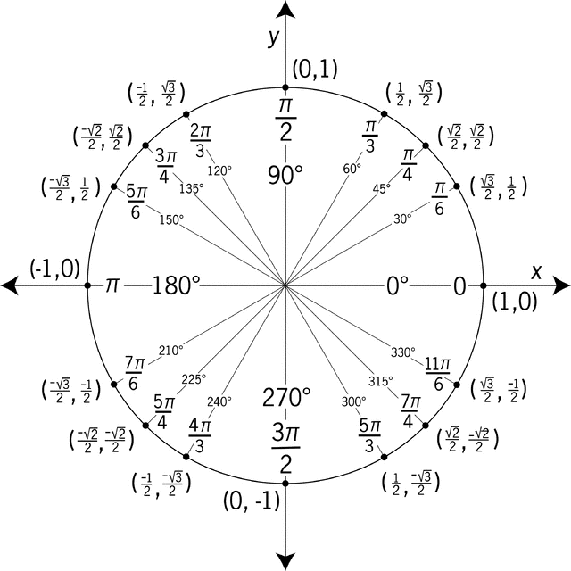

Utiliser la méthode `Translate(Vector3, Space)` disponible aux instances de `Transform`.

### Tests

1. Fonctionalité
   - `targetFrameRate` : 1
   - `amplitude` : 3
   - `radStepPerFrame` : 3.14159/2
   - `space` : *World*
2. *Self*
   - `targetFrameRate` : 60
   - `rotation` : $(45,45,45)$
   - `amplitude` : 3
   - `radStepPerFrame` : 0.1
   - `space` : *Self*

### Nombre de lignes de code

La solution de l’enseignant n’a que 3 lignes dans `Update`. Visez pour un nombre semblable.

## `WaveMotionComponentV2`

Cette composante doit faire une translation sur le *GameObject* avec un mouvement « en vague » en fonction du temps réel.

### Attributs à changer

- `float radStepPerFrame` → `float radStepPerSecond` : indique la quantité de radians à augmenter par seconde pour la valeur utilisée dans le `sin`.

### Tests

1. Fonctionalité
   - `targetFrameRate` : 60
   - `amplitude` : 3
   - `radStepPerSecond` : 3.14159/2
   - `space` : *World*
2. Fonctionalité combo
   - `targetFrameRate` : 60
   - `amplitude` : 3
   - `radStepPerSecond` : 3.14159/2
   - `space` : *Self*
   - Activer les 2 autres composantes de transformations en même temps

## Démos

[Spin](http://192.99.169.208/203/tp/203/1/spinDemo.mkv)  
[Scale](http://192.99.169.208/203/tp/203/1/scalePulsateDemo.mkv)  
[Wave](http://192.99.169.208/203/tp/203/1/waveDemo.mkv)  
[Combinaison](http://192.99.169.208/203/tp/203/1/combine.mp4)